# Part I - FordGoBike-tripdata-2019-02

## Introduction

> Introduce the dataset

> This dataset has around 183,000 entries and 16 variables, start and end of the trip aswell the trip duration in seconds. It contains data about the station details, station id, name, longitude and latitude for the start and end station, bike id, user type, member details such as birth year and gender and finally 'bike_share_for_all_trip' specifying whether the trip was part of a bike share program.

## Preliminary Wrangling

```python
# import all packages and set plots to be embedded inline
import numpy as np
import pandas as pd
import matplotlib.pyplot as plt
import seaborn as sns
%matplotlib inline

df = pd.read_csv("2019_02-fordgobike-tripdata.csv")
df.head(10)
```

|  | duration_sec | start_time | end_time | start_station_id | start_station_name | start_station_latitude | start_station_longitude | end_station_id | end_station_name | end_station_latitude | end_station_longitude | bike_id | user_type | member_birth_year | member_gender | bike_share_for_all_trip |
| --- | --- | --- | --- | --- | --- | --- | --- | --- | --- | --- | --- | --- | --- | --- | --- | --- |
| 0 | 52185 | 2019-02-28 17:32:10.1450 | 2019-03-01 08:01:55.9750 | 21.0 | Montgomery St BART Station (Market St at 2nd St) | 37.789625 | -122.400811 | 13.0 | Commercial St at Montgomery St | 37.794231 | -122.402923 | 4902 | Customer | 1984.0 | Male | No |
| 1 | 42521 | 2019-02-28 18:53:21.7890 | 2019-03-01 06:42:03.0560 | 23.0 | The Embarcadero at Steuart St | 37.791464 | -122.391034 | 81.0 | Berry St at 4th St | 37.775880 | -122.393170 | 2535 | Customer | NaN | NaN | No |
| 2 | 61854 | 2019-02-28 12:13:13.2180 | 2019-03-01 05:24:08.1460 | 86.0 | Market St at Dolores St | 37.769305 | -122.426826 | 3.0 | Powell St BART Station (Market St at 4th St) | 37.786375 | -122.404904 | 5905 | Customer | 1972.0 | Male | No |
| 3 | 36490 | 2019-02-28 17:54:26.0100 | 2019-03-01 04:02:36.8420 | 375.0 | Grove St at Masonic Ave | 37.774836 | -122.446546 | 70.0 | Central Ave at Fell St | 37.773311 | -122.444293 | 6638 | Subscriber | 1989.0 | Other | No |
| 4 | 1585 | 2019-02-28 23:54:18.5490 | 2019-03-01 00:20:44.0740 | 7.0 | Frank H Ogawa Plaza | 37.804562 | -122.271738 | 222.0 | 10th Ave at E 15th St | 37.792714 | -122.248780 | 4898 | Subscriber | 1974.0 | Male | Yes |
| 5 | 1793 | 2019-02-28 23:49:58.6320 | 2019-03-01 00:19:51.7600 | 93.0 | 4th St at Mission Bay Blvd S | 37.770407 | -122.391198 | 323.0 | Broadway at Kearny | 37.798014 | -122.405950 | 5200 | Subscriber | 1959.0 | Male | No |
| 6 | 1147 | 2019-02-28 23:55:35.1040 | 2019-03-01 00:14:42.5880 | 300.0 | Palm St at Willow St | 37.317298 | -121.884995 | 312.0 | San Jose Diridon Station | 37.329732 | -121.901782 | 3803 | Subscriber | 1983.0 | Female | No |
| 7 | 1615 | 2019-02-28 23:41:06.7660 | 2019-03-01 00:08:02.7560 | 10.0 | Washington St at Kearny St | 37.795393 | -122.404770 | 127.0 | Valencia St at 21st St | 37.756708 | -122.421025 | 6329 | Subscriber | 1989.0 | Male | No |
| 8 | 1570 | 2019-02-28 23:41:48.7900 | 2019-03-01 00:07:59.7150 | 10.0 | Washington St at Kearny St | 37.795393 | -122.404770 | 127.0 | Valencia St at 21st St | 37.756708 | -122.421025 | 6548 | Subscriber | 1988.0 | Other | No |
| 9 | 1049 | 2019-02-28 23:49:47.6990 | 2019-03-01 00:07:17.0250 | 19.0 | Post St at Kearny St | 37.788975 | -122.403452 | 121.0 | Mission Playground | 37.759210 | -122.421339 | 6488 | Subscriber | 1992.0 | Male | No |

> Load in your dataset and describe its properties through the questions below. Try and motivate your exploration goals through this section.

> Note that the collective size of all your files in the current worksapce **must not exceed 1 GB** in total.

### What is the structure of your dataset?

> The dataset has about 183,000 rows and 16 columns, i've talked about the dataset in the introduction but i will clarify a few more things, we have different datatypes in the dataset, Numerical data: (e.g. duration, birth year ), categorical data : (e.g. user_type, member_gender), datetime data : (e.g. start_time, end_time)

### What is/are the main feature(s) of interest in your dataset?

> duration_sec

> user_type

### What features in the dataset do you think will help support your investigation into your feature(s) of interest?

> (birth_year, bike_share_for_all_trip, member_gender)

I will create a function to reduce the code for cleaning the dataframe from duplicate values and drop rows that contain NaN values

```python
def clean_dataframe(df):

    # counts duplicates and NaN values
    duplicate_count = df.duplicated().sum()
    nan_count = df.isna().sum().sum()

    print(f"Number of duplicate rows: {duplicate_count}")
    print(f"Number of NaN values: {nan_count}")

    if duplicate_count > 0:
        df = df.drop_duplicates().reset_index(drop=True)
        print("Duplicates removed.")

    if nan_count > 0:
        df = df.dropna().reset_index(drop=True)
        print("Rows with NaN values removed.")

    return df
```

```python
df.info()
```

```
<class 'pandas.core.frame.DataFrame'>
RangeIndex: 183412 entries, 0 to 183411
Data columns (total 16 columns):
 #   Column                   Non-Null Count   Dtype
---  ------                   --------------   -----
 0   duration_sec             183412 non-null  int64
 1   start_time               183412 non-null  object
 2   end_time                 183412 non-null  object
 3   start_station_id         183215 non-null  float64
 4   start_station_name       183215 non-null  object
 5   start_station_latitude   183412 non-null  float64
 6   start_station_longitude  183412 non-null  float64
 7   end_station_id           183215 non-null  float64
 8   end_station_name         183215 non-null  object
 9   end_station_latitude     183412 non-null  float64
 10  end_station_longitude    183412 non-null  float64
 11  bike_id                  183412 non-null  int64
 12  user_type                183412 non-null  object
 13  member_birth_year        175147 non-null  float64
 14  member_gender            175147 non-null  object
 15  bike_share_for_all_trip  183412 non-null  object
dtypes: float64(7), int64(2), object(7)
memory usage: 22.4+ MB
```

```python
print(df.isna().sum())
```

```
duration_sec                  0
start_time                    0
end_time                      0
start_station_id            197
start_station_name          197
start_station_latitude        0
start_station_longitude       0
end_station_id              197
end_station_name            197
end_station_latitude          0
end_station_longitude         0
bike_id                       0
user_type                     0
member_birth_year          8265
member_gender              8265
bike_share_for_all_trip       0
dtype: int64
```

```python
df = clean_dataframe(df)
```

```
Number of duplicate rows: 0
Number of NaN values: 17318
Rows with NaN values removed.
```

```python
df.info()
```

```
<class 'pandas.core.frame.DataFrame'>
RangeIndex: 174952 entries, 0 to 174951
Data columns (total 16 columns):
 #   Column                   Non-Null Count   Dtype
---  ------                   --------------   -----
 0   duration_sec             174952 non-null  int64
 1   start_time               174952 non-null  object
 2   end_time                 174952 non-null  object
 3   start_station_id         174952 non-null  float64
 4   start_station_name       174952 non-null  object
 5   start_station_latitude   174952 non-null  float64
 6   start_station_longitude  174952 non-null  float64
 7   end_station_id           174952 non-null  float64
 8   end_station_name         174952 non-null  object
 9   end_station_latitude     174952 non-null  float64
 10  end_station_longitude    174952 non-null  float64
 11  bike_id                  174952 non-null  int64
 12  user_type                174952 non-null  object
 13  member_birth_year        174952 non-null  float64
 14  member_gender            174952 non-null  object
 15  bike_share_for_all_trip  174952 non-null  object
dtypes: float64(7), int64(2), object(7)
memory usage: 21.4+ MB
```

```python
df.describe()
```

|  | duration_sec | start_station_id | start_station_latitude | start_station_longitude | end_station_id | end_station_latitude | end_station_longitude | bike_id | member_birth_year |
| --- | --- | --- | --- | --- | --- | --- | --- | --- | --- |
| count | 174952.000000 | 174952.000000 | 174952.000000 | 174952.000000 | 174952.000000 | 174952.000000 | 174952.000000 | 174952.000000 | 174952.000000 |
| mean | 704.002744 | 139.002126 | 37.771220 | -122.351760 | 136.604486 | 37.771414 | -122.351335 | 4482.587555 | 1984.803135 |
| std | 1642.204905 | 111.648819 | 0.100391 | 0.117732 | 111.335635 | 0.100295 | 0.117294 | 1659.195937 | 10.118731 |
| min | 61.000000 | 3.000000 | 37.317298 | -122.453704 | 3.000000 | 37.317298 | -122.453704 | 11.000000 | 1878.000000 |
| 25% | 323.000000 | 47.000000 | 37.770407 | -122.411901 | 44.000000 | 37.770407 | -122.411647 | 3799.000000 | 1980.000000 |
| 50% | 510.000000 | 104.000000 | 37.780760 | -122.398279 | 101.000000 | 37.781010 | -122.397437 | 4960.000000 | 1987.000000 |
| 75% | 789.000000 | 239.000000 | 37.797320 | -122.283093 | 238.000000 | 37.797673 | -122.286533 | 5505.000000 | 1992.000000 |
| max | 84548.000000 | 398.000000 | 37.880222 | -121.874119 | 398.000000 | 37.880222 | -121.874119 | 6645.000000 | 2001.000000 |

We can notice that the minimum birth year is 1878 which means they would be around 120 years at 2019, which doesn't make sense so i decided to drop all rows with birth year less than 1940 to make the data more accurate.

```python
df = df[df['member_birth_year'] > 1940]
df.describe()
```

|  | duration_sec | start_station_id | start_station_latitude | start_station_longitude | end_station_id | end_station_latitude | end_station_longitude | bike_id | member_birth_year |
| --- | --- | --- | --- | --- | --- | --- | --- | --- | --- |
| count | 174749.000000 | 174749.000000 | 174749.000000 | 174749.000000 | 174749.000000 | 174749.000000 | 174749.000000 | 174749.000000 | 174749.000000 |
| mean | 704.300563 | 139.024092 | 37.771201 | -122.351718 | 136.643683 | 37.771397 | -122.351294 | 4482.315183 | 1984.877665 |
| std | 1643.075498 | 111.651112 | 0.100445 | 0.117778 | 111.352470 | 0.100349 | 0.117340 | 1659.248113 | 9.871342 |
| min | 61.000000 | 3.000000 | 37.317298 | -122.453704 | 3.000000 | 37.317298 | -122.453704 | 11.000000 | 1941.000000 |
| 25% | 323.000000 | 47.000000 | 37.770407 | -122.411901 | 44.000000 | 37.770407 | -122.411647 | 3799.000000 | 1980.000000 |
| 50% | 511.000000 | 104.000000 | 37.780787 | -122.398279 | 101.000000 | 37.781010 | -122.397437 | 4960.000000 | 1987.000000 |
| 75% | 789.000000 | 239.000000 | 37.797320 | -122.283093 | 238.000000 | 37.797673 | -122.285633 | 5505.000000 | 1992.000000 |
| max | 84548.000000 | 398.000000 | 37.880222 | -121.874119 | 398.000000 | 37.880222 | -121.874119 | 6645.000000 | 2001.000000 |

## Univariate Exploration

> In this section, investigate distributions of individual variables. If you see unusual points or outliers, take a deeper look to clean things up and prepare yourself to look at relationships between variables.

## Is there outliers or is the data skewed?

```
(0.0, 10000.0)
```

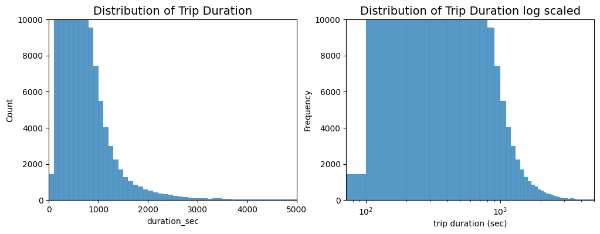

```python
fig, (ax1, ax2) = plt.subplots(1, 2, figsize=(12, 4))
bins = np.arange(0,df['duration_sec'].max() + 100, 100)
sns.histplot(data=df, x = 'duration_sec', bins = bins, ax = ax1)
ax1.set_xlim(0, 5000)
ax1.set_ylim(0,10000)
ax1.set_title('Distribution of Trip Duration', fontsize=14)

#plt.hist(data=df, x='duration_sec', bins = bins)
sns.histplot(data=df, x = 'duration_sec', bins = bins, ax = ax2)
ax2.set_xscale('log')
ax2.set_xlabel('trip duration (sec)')
ax2.set_ylabel('Frequency')

#plt.xscale('log')
#plt.xlabel('trip duration (sec)')
#plt.ylabel('Frequency')
plt.title('Distribution of Trip Duration log scaled', fontsize=14)
plt.xlim(0, 5000)
plt.ylim(0,10000)
```

We applied log scaling on the x-axis to solve the skewness issue as seen in the plot on the left, most of the data is lying between 100-1000 seconds.

## What is the ratio for subscribers and customers?

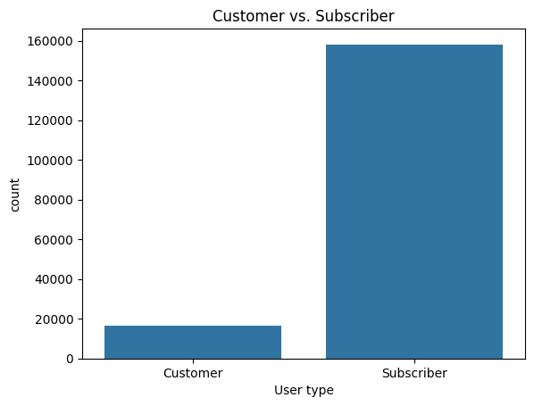

```python
sns.countplot(data= df, x = 'user_type')
plt.xlabel('User type')
plt.title("Customer vs. Subscriber")
```

Using countplot we can see the ratio between subscribers and customers, subscribers make about 90% of the data with about 160,000 while customer are around 20,000.

### Of the features you investigated, were there any unusual distributions? Did you perform any operations on the data to tidy, adjust, or change the form of the data? If so, why did you do this?

> I did some basic cleaning operations such as dropping rows with NaN values and and removing outliers.

## Bivariate Exploration

> In this section, investigate relationships between pairs of variables in your data. Make sure the variables that you cover here have been introduced in some fashion in the previous section (univariate exploration).

## Does birth year directly affect trip duration?

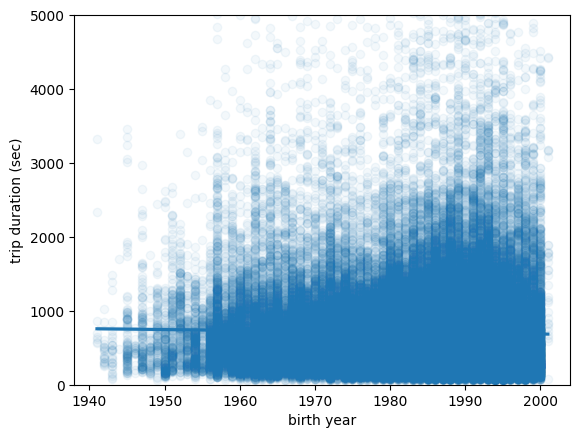

```python
sns.regplot(data=df, y = 'duration_sec', x = 'member_birth_year', scatter_kws={'alpha':1/20})
plt.ylim(0,5000)
plt.xlabel('birth year')
plt.ylabel('trip duration (sec)')
```

Even with applying transparency on the data, we can notice that the avg trip duration is under 1000 seconds and there is more users on the right side (younger side) of the birth year variable. We can notice though that there is a decent amount of older people on the higher end of the trip duration.

**The above plot may take a 2-3 minutes to run**

## Which user type usually has more trip duration?

```
(0.0, 5000.0)
```

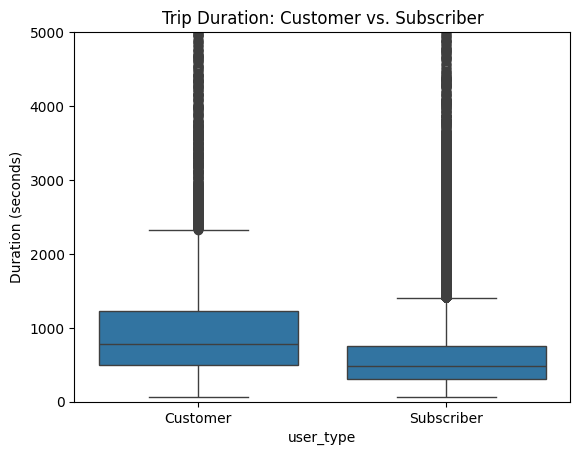

```python
sns.boxplot(data=df, x="user_type", y="duration_sec")
plt.title("Trip Duration: Customer vs. Subscriber")
plt.ylabel("Duration (seconds)")
plt.ylim(0,5000)
```

The box plot above shows that customer's duration time's mean, 1st and 3rd quantile is all higher than subscribers'.

## Does Shared programs users contain more or less trip duration than individual users?

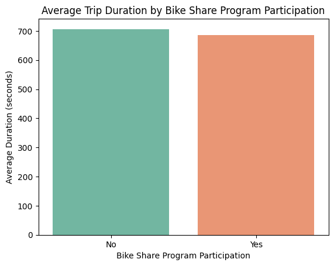

```python
# calculate avg trip duration for shared programs
avg_duration = df.groupby("bike_share_for_all_trip")["duration_sec"].mean().reset_index()
sns.barplot(data= avg_duration, x = 'bike_share_for_all_trip', y = 'duration_sec', palette= "Set2")
plt.title("Average Trip Duration by Bike Share Program Participation")
plt.xlabel("Bike Share Program Participation")
plt.ylabel("Average Duration (seconds)")
plt.show()
```

We can notice that trip duration is not affected by shared programs as seen in the bar chart above, as the data is close in range.

### Did you observe any interesting relationships between the other features (not the main feature(s) of interest)?

> birth year doesn't directly affect trip duration, meaning old people can endure long trips such as younger people.

## Multivariate Exploration

> Create plots of three or more variables to investigate your data even further. Make sure that your investigations are justified, and follow from your work in the previous sections.

## Does member gender, user type, and shared programs users affect trip duration?

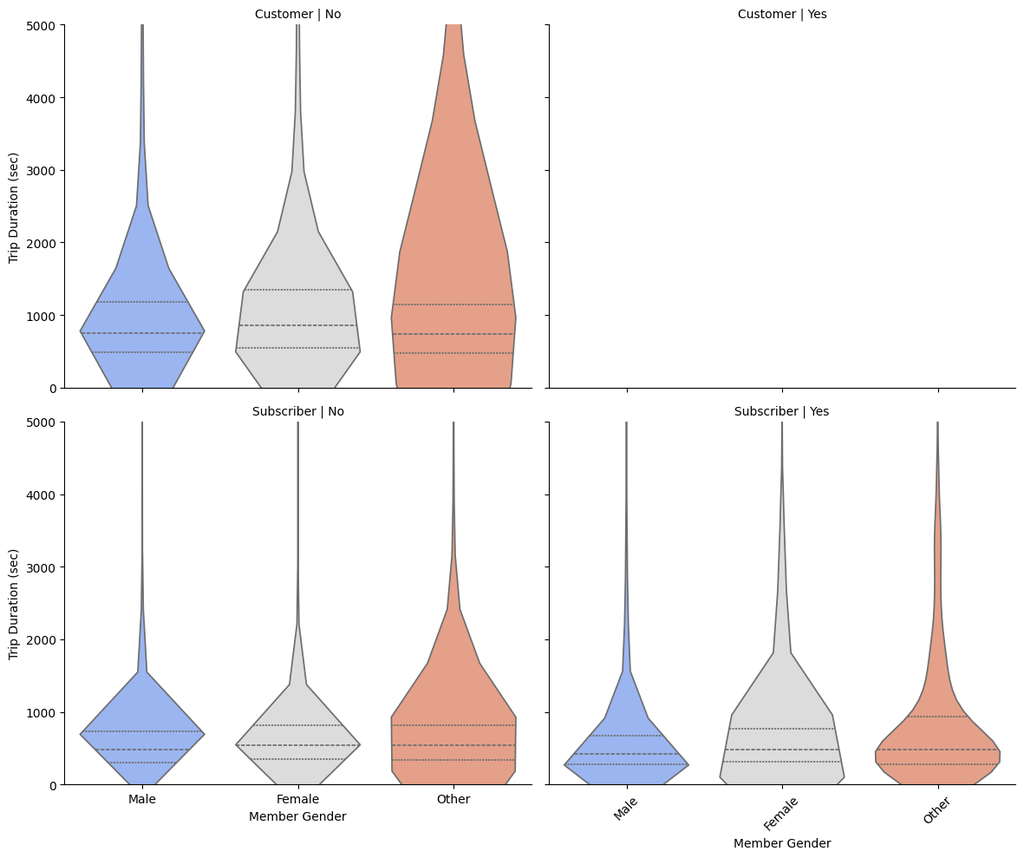

```python
# we set the gender order to make it look more clean in the plot
gender_order = ["Male", "Female", "Other"]

g = sns.FacetGrid(df, row='user_type', col='bike_share_for_all_trip', height=5, aspect=1.2)

g.map_dataframe(sns.violinplot, x='member_gender', y='duration_sec', palette='coolwarm', inner='quartile', order = gender_order)

g.set_axis_labels("Member Gender", "Trip Duration (sec)")
g.set_titles(row_template="{row_name}", col_template="{col_name}")
plt.xticks(rotation=45)
plt.tight_layout()
plt.ylim(0,5000)

plt.show();
```

Surprisingly there is no data for customers in shared programs, we can see again that customers have higher trip duration than subscribers.

## Is trip duration dependemt on member gender, user type or birth year?

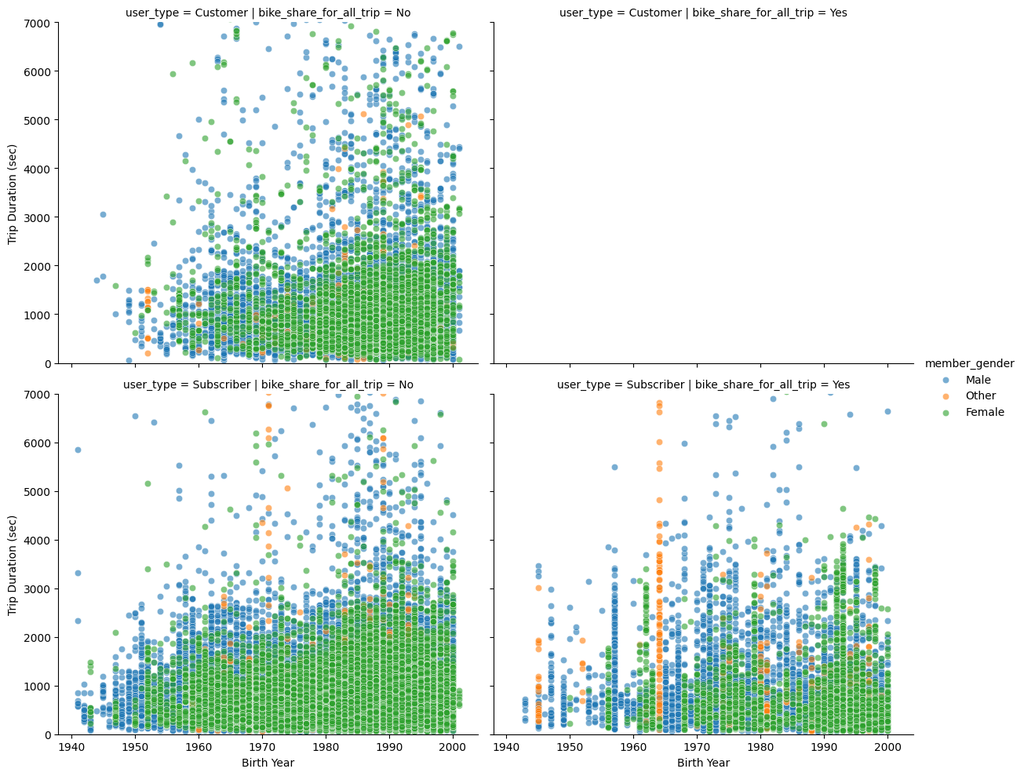

```python
g = sns.FacetGrid(df, col='bike_share_for_all_trip', row='user_type', hue='member_gender', height=5, aspect=1.2)
g.map_dataframe(sns.scatterplot, x='member_birth_year', y='duration_sec', alpha=0.6)

g.set_axis_labels("Birth Year", "Trip Duration (sec)")
g.add_legend()
plt.ylim(0,7000)
plt.show()
```

The facetgrid scatterplot above assures the conclusion we got to in the last plot that there is no data about customers being in shared programs. We can notice that 'other' gender has less data compared to male and female.

### Talk about some of the relationships you observed in this part of the investigation. Were there features that strengthened each other in terms of looking at your feature(s) of interest?

> We can notice again that subscribers consistently take shorter trips than customers, we can notice almost always females has higher trip duration than other genders.

### Were there any interesting or surprising interactions between features?

> In both facet viloinplot and scatterplot we notice that there is no data for customer in a shared program!

## Conclusions

> Throgh the visualizations across univariate,bivariate, and multivariate we found that:

> Most of the users are subscribers.

> Subscribers usually tend to take shorter trips while customers take longer trips.

> Older people take longer trips, but age has weak correlation with duration.

> Customers don't attend shared programs

```python
# We save the cleaned df and use it in the other notebook to show polished visualization
df.to_csv("cleaned_data.csv", index=False)
```